# DNA primase large subunit

Fold-switch pair **3l9qB_4rr2D** — **3l9qB** vs **4rr2D**

Homo sapiens

## Figure 1: Phylogenetic tree with per-cluster fold-preference heatmap.

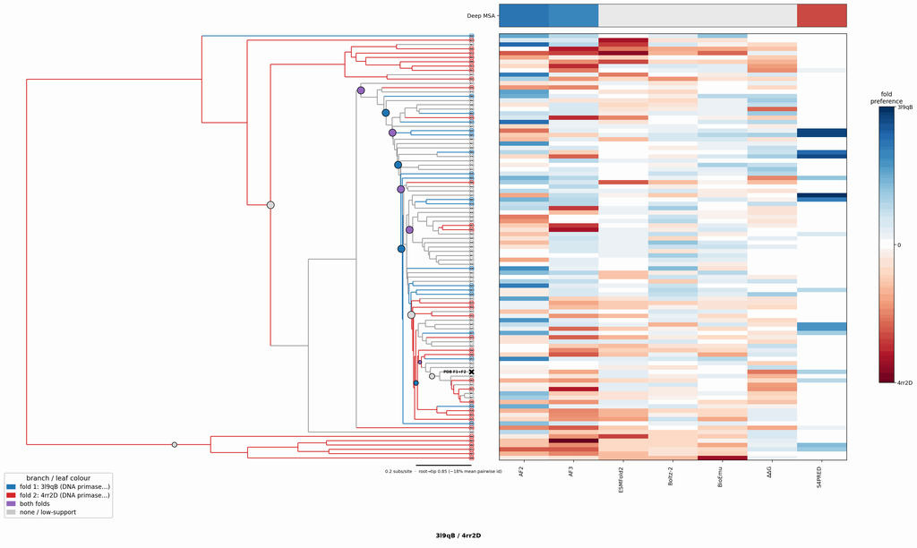

## Figure 2: Aligned overlay (both folds superposed)

The single fold-switching chain of each fold superposed by TM-align; waters hidden, any ligand shown as green sticks. Grey = structurally conserved core, colour = divergent (fold-switching) region.

3l9qB (DNA primase large subunit) · monomer4rr2D (DNA primase large subunit) · dimerLigand SF4 (bound to 3l9qB), Ligand SF4 (bound to 4rr2D)

TM-score: 0.872 · Trigger class: protein_binding

Aligned overlay

Loading...

## Figure 3: The two folds, side by side

Each fold is coloured by per-residue Cα deviation between the two superposed structures: grey ≈ conserved core, full colour = structurally divergent (fold-switching) region.

3l9qB (DNA primase large subunit)

4rr2D (DNA primase large subunit)

0 Å5≥10 Å

3l9qB (DNA primase large subunit)

Loading...

4rr2D (DNA primase large subunit)

Loading...

## Figure 4: Best-cluster predicted contact maps over the two true folds.

Predicted contact maps (MSA-Transformer) for the clusters best matching each fold, over the true contacts of fold 1 (upper triangle) and fold 2 (lower). Divergent contacts between clusters are the contact-level signature of fold-switching.

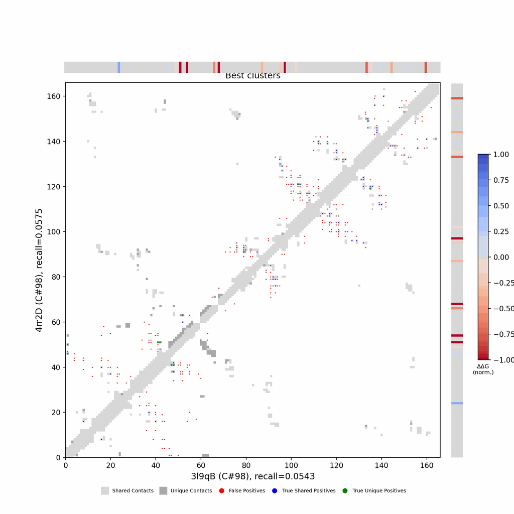

## Figure 5: Per-residue ΔΔG fold-preference contribution

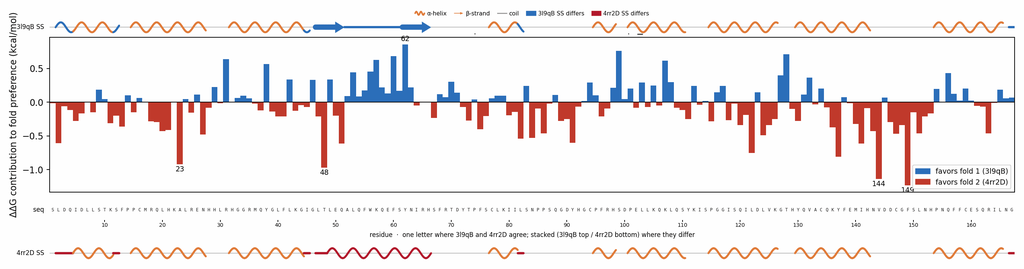

**More figures**

## Figure 6: Deep-MSA contact map panel / Best clusters contact map panel

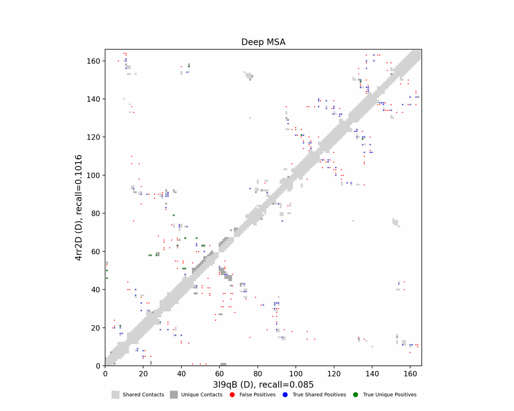

Deep-MSA contact map panel

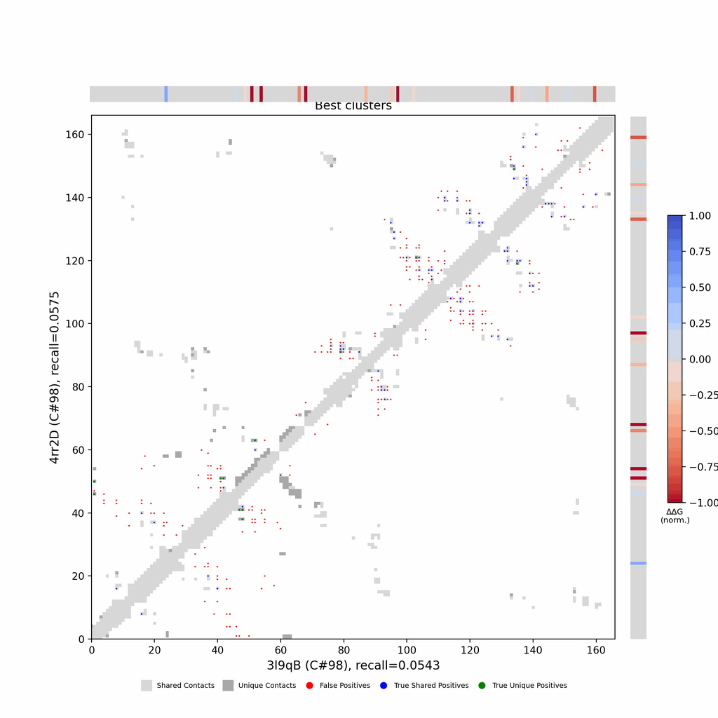

Best clusters contact map panel

## Figure 7: All clusters contact-map mosaic (small multiples).

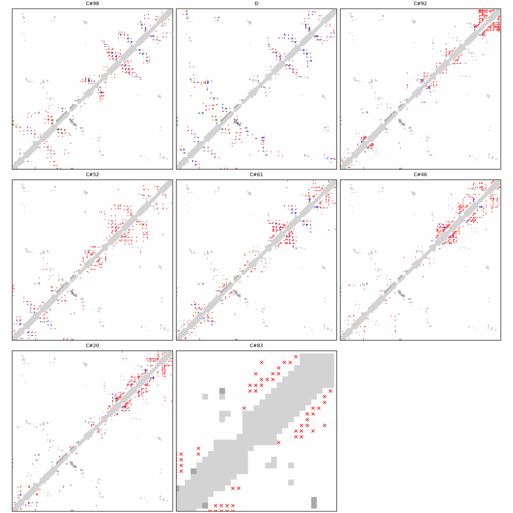

## Figure 8: Phylo null: tree with shuffled cluster fold labels.

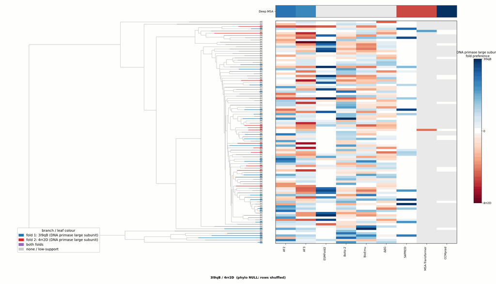

## Cluster metrics table

Per-cluster metrics underlying the figures above.

| cluster | n | neff | AF2_TM1 | AF2_TM2 | AF3_TM1 | AF3_TM2 | RE-MSAT-COM | RE-MSAT1 | RE-MSAT2 | ESM_SEQIDS | ESM_TM1 | ESM_TM2 | ΔΔG_Bias | ΔΔG_Bias_std | ΔΔG_frac_F1 | Boltz2_pref | S4PRED_pref | CCMpred_pref | BioEmu_pref |
| --- | --- | --- | --- | --- | --- | --- | --- | --- | --- | --- | --- | --- | --- | --- | --- | --- | --- | --- | --- |
| Deep | - | - | 0.88 | 0.61 | 0.87 | 0.57 | 0.4 | 0.35 | 0.38 | - | - | - | - | - | - | - | -0.03 | 0.01 | - |
| 000 | 531.0 | 346.0 | 0.75 | 0.48 | 0.87 | 0.5 | - | - | 0.01 | 001; 001; 009; 009; 003; 008; 003; 008; 002; 002 | 0.83 ± 0.02 | 0.50 ± 0.09 | 40.02 | 23.08 | 0.9 | 0.19 | -0.03 | 0.0 | 0.22 |
| 001 | 167.0 | 5.0 | 0.42 | 0.22 | 0.4 | 0.2 | - | - | 0.0 | 001; 001; 009; 009; 008; 008; 003; 002; 003; 002 | 0.84 ± 0.02 | 0.48 ± 0.06 | 27.22 | 22.82 | 1.0 | 0.15 | -0.03 | 0.0 | 0.14 |
| 002 | 139.0 | 3.0 | 0.44 | 0.36 | 0.54 | 0.36 | - | - | 0.0 | 007; 007; 003; 009; 003; 009; 002; 002; 001; 008 | 0.82 ± 0.02 | 0.49 ± 0.05 | 19.49 | 16.15 | 0.8 | 0.14 | -0.03 | 0.0 | 0.16 |
| 003 | 139.0 | 7.0 | 0.3 | 0.24 | 0.38 | 0.35 | - | - | 0.0 | 001; 001; 008; 007; 007; 008; 004; 004; 003; 003 | 0.82 ± 0.01 | 0.53 ± 0.09 | 45.57 | 22.94 | 1.0 | 0.15 | -0.03 | 0.0 | 0.09 |
| 004 | 122.0 | 63.0 | 0.3 | 0.19 | 0.4 | 0.21 | - | - | 0.01 | 001; 008; 008; 001; 004; 004; 003; 003; 006; 006 | 0.83 ± 0.01 | 0.48 ± 0.07 | 59.64 | 24.76 | 1.0 | 0.11 | -0.03 | 0.0 | 0.15 |
| 005 | 120.0 | 30.0 | 0.57 | 0.55 | 0.87 | 0.53 | - | - | 0.0 | 001; 001; 003; 003; 010; 010; 009; 006; 004; 004 | 0.83 ± 0.01 | 0.51 ± 0.08 | 45.04 | 30.04 | 0.9 | 0.22 | -0.03 | 0.0 | 0.18 |
| 006 | 120.0 | 36.0 | 0.42 | 0.33 | 0.39 | 0.36 | - | - | 0.0 | 001; 001; 003; 008; 008; 003; 006; 006; 004; 004 | 0.81 ± 0.02 | 0.45 ± 0.05 | 46.39 | 24.4 | 0.9 | 0.09 | -0.03 | 0.0 | 0.1 |
| 007 | 119.0 | 12.0 | 0.47 | 0.49 | 0.42 | 0.49 | - | - | 0.02 | 003; 009; 009; 003; 004; 004; 005; 006; 008; 008 | 0.82 ± 0.00 | 0.54 ± 0.05 | 35.96 | 30.46 | 0.7 | 0.12 | -0.03 | 0.0 | 0.16 |
| 008 | 118.0 | 46.0 | 0.68 | 0.5 | 0.46 | 0.54 | - | - | 0.01 | 001; 001; 007; 007; 005; 005; 003; 006; 006; 003 | 0.82 ± 0.02 | 0.53 ± 0.09 | 30.15 | 24.81 | 1.0 | 0.26 | -0.03 | 0.0 | 0.14 |
| 009 | 114.0 | 10.0 | 0.6 | 0.51 | 0.63 | 0.52 | - | - | 0.02 | 001; 001; 003; 003; 008; 008; 005; 007; 007; 005 | 0.83 ± 0.03 | 0.50 ± 0.07 | 32.88 | 31.38 | 0.9 | 0.16 | -0.03 | 0.0 | 0.13 |
| 010 | 101.0 | 53.0 | 0.46 | 0.4 | 0.84 | 0.57 | - | - | 0.01 | 003; 003; 001; 009; 009; 005; 001; 005; 010; 010 | 0.84 ± 0.01 | 0.53 ± 0.10 | 53.42 | 20.66 | 1.0 | 0.13 | -0.03 | 0.0 | 0.14 |
| 011 | 100.0 | 14.0 | 0.56 | 0.52 | 0.76 | 0.54 | - | - | 0.02 | 006; 006; 007; 007; 005; 005; 009; 008; 009; 008 | 0.83 ± 0.01 | 0.56 ± 0.03 | 43.82 | 27.14 | 1.0 | 0.13 | -0.03 | 0.0 | 0.13 |
| 012 | 87.0 | 48.0 | 0.41 | 0.41 | 0.42 | 0.5 | - | - | 0.0 | 002; 002; 003; 009; 009; 003; 004; 004; 007; 007 | 0.84 ± 0.01 | 0.54 ± 0.07 | 13.4 | 11.46 | 0.9 | 0.21 | -0.03 | 0.0 | 0.16 |
| 013 | 86.0 | 45.0 | 0.55 | 0.47 | 0.84 | 0.59 | - | - | 0.01 | 001; 001; 002; 002; 005; 005; 007; 007; 008; 008 | 0.82 ± 0.03 | 0.52 ± 0.05 | 24.6 | 15.89 | 0.9 | 0.17 | -0.03 | 0.0 | 0.16 |
| 014 | 86.0 | 34.0 | 0.67 | 0.5 | 0.87 | 0.49 | - | - | 0.0 | - | - | - | 53.92 | 26.47 | 1.0 | 0.21 | -0.03 | - | 0.14 |
| 015 | 84.0 | 33.0 | 0.41 | 0.48 | 0.86 | 0.51 | - | - | 0.0 | - | - | - | 37.87 | 30.91 | 0.8 | 0.09 | 0.02 | - | 0.12 |
| 016 | 84.0 | 27.0 | 0.36 | 0.29 | 0.38 | 0.25 | - | - | 0.01 | - | - | - | 53.89 | 23.64 | 0.9 | 0.13 | -0.03 | - | 0.1 |
| 017 | 83.0 | 55.0 | 0.79 | 0.44 | 0.78 | 0.51 | - | - | 0.0 | - | - | - | 57.79 | 30.15 | 0.9 | 0.16 | -0.03 | - | 0.18 |
| 018 | 83.0 | 10.0 | 0.28 | 0.32 | 0.43 | 0.41 | - | - | 0.0 | - | - | - | 44.18 | 23.48 | 1.0 | 0.11 | -0.03 | - | 0.09 |
| 019 | 80.0 | 8.0 | 0.45 | 0.56 | 0.86 | 0.61 | - | - | 0.0 | - | - | - | 33.89 | 25.88 | 0.7 | 0.22 | -0.03 | - | 0.13 |
| 020 | 80.0 | 7.0 | 0.41 | 0.35 | 0.4 | 0.32 | 0.01 | 0.01 | 0.0 | - | - | - | 6.44 | 7.57 | 0.8 | 0.17 | -0.02 | - | 0.13 |
| 021 | 75.0 | 14.0 | 0.61 | 0.54 | 0.87 | 0.56 | - | - | 0.0 | - | - | - | 61.97 | 26.59 | 1.0 | 0.18 | -0.03 | - | 0.15 |
| 022 | 75.0 | 21.0 | 0.36 | 0.26 | 0.36 | 0.29 | - | - | 0.02 | - | - | - | 32.47 | 20.0 | 0.9 | 0.1 | -0.03 | - | 0.1 |
| 023 | 73.0 | 8.0 | 0.41 | 0.39 | 0.39 | 0.41 | - | - | 0.0 | - | - | - | 35.81 | 28.18 | 1.0 | 0.14 | -0.03 | - | 0.09 |
| 024 | 70.0 | 52.0 | 0.62 | 0.44 | 0.84 | 0.56 | - | - | 0.02 | - | - | - | 29.55 | 15.75 | 1.0 | 0.22 | -0.03 | - | 0.12 |
| 025 | 68.0 | 37.0 | 0.6 | 0.59 | 0.83 | 0.57 | - | - | 0.04 | - | - | - | 36.2 | 23.76 | 0.9 | 0.18 | -0.03 | - | 0.14 |
| 026 | 67.0 | 17.0 | 0.36 | 0.44 | 0.6 | 0.57 | - | - | 0.02 | - | - | - | 26.93 | 18.83 | 1.0 | 0.15 | -0.03 | - | 0.13 |
| 027 | 65.0 | 40.0 | 0.48 | 0.45 | 0.87 | 0.56 | - | - | 0.03 | - | - | - | 28.22 | 24.36 | 0.7 | 0.22 | -0.03 | - | 0.13 |
| 028 | 61.0 | 21.0 | 0.81 | 0.51 | 0.86 | 0.59 | - | - | 0.01 | - | - | - | 38.34 | 24.53 | 0.9 | 0.29 | -0.03 | - | 0.11 |

[output cut: 70 more lines]